## Question

Exercises 6.4, 6.6, 6.13(pages 178-180, Statistical Computing with R, 2nd edition).

Monte Carlo experiment

(2)Use R function rbenchmark::benchmark to count computation time(with 1000 replications), denoted by a_n

(3)Regress a_n on t_n :=nlog(n), and graphically show the results(scatter plot regression line).

## 1 问题一（6.4）

6.4 Write a function to compute a Monte Carlo estimate of the Beta(3, 3) cdf, and use the function to estimate (F(x) for x = 0.1, 0.2, …, 0.9. Compare the estimates with the values returned by the pbeta function in R.

### 1.1 问题分析

这个问题可以拆分为三部分：

1、创建一个蒙特卡洛模拟函数，用于估计 Beta (3, 3) 分布的累积分布函数（CDF）

2、用这个函数计算 x=0.1 到 0.9（间隔 0.1）时的 CDF 估计值

3、将这些蒙特卡洛估计值与 R 语言内置函数pbeta计算的精确 CDF 值进行对比

### 1.2 编写蒙特卡洛函数

```r
beta_cdf_mc_estimate <- function(quantile, shape_a = 3, shape_b = 3, sample_size = 1e6) {
  beta_samples <- rbeta(sample_size, shape1 = shape_a, shape2 = shape_b)
  mean(beta_samples <= quantile)
}

eval_points <- seq(from = 0.1, to = 0.9, by = 0.1)

mc_estimates <- numeric(length(eval_points))
exact_values <- numeric(length(eval_points))

for (idx in seq_along(eval_points)) {
  current_x <- eval_points[idx]
  mc_estimates[idx] <- beta_cdf_mc_estimate(current_x, shape_a = 3, shape_b = 3)
  exact_values[idx] <- pbeta(current_x, shape1 = 3, shape2 = 3)
}

result_comparison <- data.frame(
  分位点 = eval_points,
  蒙特卡洛估计 = mc_estimates,
  理论精确值 = exact_values,
  估计误差 = mc_estimates - exact_values
)

print(result_comparison, digits = 6)
```

```
##   分位点 蒙特卡洛估计 理论精确值  估计误差
## 1    0.1     0.008611    0.00856  0.000051
## 2    0.2     0.057991    0.05792  0.000071
## 3    0.3     0.163007    0.16308 -0.000073
## 4    0.4     0.317366    0.31744 -0.000074
## 5    0.5     0.500137    0.50000  0.000137
## 6    0.6     0.682421    0.68256 -0.000139
## 7    0.7     0.837091    0.83692  0.000171
## 8    0.8     0.942036    0.94208 -0.000044
## 9    0.9     0.991492    0.99144  0.000052
```

### 1.3 结果分析

从结果来看，蒙特卡洛估计的 Beta (3, 3) 分布 CDF 与pbeta的精确值非常接近。

## 2 问题二（6.6）

6.6 In Example 6.7 the control variate approach was illustrated for Monte Carlo integration of

$$\theta = \int_0^1 e^x \, dx$$

Now consider the antithetic variate approach. Compute

$$\text{Cov}(e^U, e^{1-U}) \quad \text{and} \quad \text{Var}(e^U +
e^{1-U}), \quad \text{where } U \sim \text{Uniform}(0,1).$$

What is the percent reduction in variance of θ that can be achieved using antithetic variates (compared with simple MC)?

### 2.1 问题分析

这个问题需要我针对积分的蒙特卡洛估计，计算协方差和方差。 对比“对偶变量法”和“简单蒙特卡洛法”，算出用对偶变量法估计θ时，方差能减少多少。

### 2.3 R语言求解验证

```r
set.seed(66)

n <- 1e6
U <- runif(n)
X <- exp(U)
Y <- exp(1 - U)

cov_xy <- cov(X, Y)
var_x_plus_y <- var(X + Y)
var_mc <- var(X)
var_av <- var_x_plus_y / 4
reduction <- (1 - var_av / var_mc) * 100

cat("===== 模拟结果 =====\n")
```

```
## ===== 模拟结果 =====
```

```r
cat(sprintf("Cov(e^U, e^(1-U)): %.6f\n", cov_xy))
```

```
## Cov(e^U, e^(1-U)): -0.234604
```

```r
cat(sprintf("Var(e^U + e^(1-U)): %.6f\n", var_x_plus_y))
```

```
## Var(e^U + e^(1-U)): 0.015661
```

```r
cat(sprintf("简单蒙特卡洛方差: %.6f\n", var_mc))
```

```
## 简单蒙特卡洛方差: 0.242491
```

```r
cat(sprintf("对偶变量法方差: %.6f\n", var_av))
```

```
## 对偶变量法方差: 0.003915
```

```r
cat(sprintf("方差减少百分比: %.2f%%\n\n", reduction))
```

```
## 方差减少百分比: 98.39%
```

```r
e <- exp(1)

E_X <- integrate(function(u) exp(u), 0, 1)$value
E_X2 <- integrate(function(u) exp(2*u), 0, 1)$value
Var_X <- E_X2 - E_X^2

E_XY <- e
Cov_XY <- E_XY - E_X * E_X

Var_XY_sum <- 2*Var_X + 2*Cov_XY
Var_AV <- Var_XY_sum / 4
reduction_theo <- (1 - Var_AV / Var_X) * 100

cat("===== 理论结果 =====\n")
```

```
## ===== 理论结果 =====
```

```r
cat(sprintf("Cov(e^U, e^(1-U)): %.6f\n", Cov_XY))
```

```
## Cov(e^U, e^(1-U)): -0.234211
```

```r
cat(sprintf("Var(e^U + e^(1-U)): %.6f\n", Var_XY_sum))
```

```
## Var(e^U + e^(1-U)): 0.015650
```

```r
cat(sprintf("简单蒙特卡洛方差: %.6f\n", Var_X))
```

```
## 简单蒙特卡洛方差: 0.242036
```

```r
cat(sprintf("对偶变量法方差: %.6f\n", Var_AV))
```

```
## 对偶变量法方差: 0.003912
```

```r
cat(sprintf("方差减少百分比: %.2f%%\n", reduction_theo))
```

```
## 方差减少百分比: 98.38%
```

### 2.4 结果分析

从结果来看，模拟结果与理论结果几乎一样，说明对偶变量法能够提升蒙特卡洛估计的效率。

## 3 问题三（6.13）

6.13 Find two importance functions $f_1$ and $f_2$ that are supported on $(1, \infty)$ and are “close” to
$$g(x) = \frac{x^2}{\sqrt{2\pi}} e^{-x^2/2}, \quad x > 1.$$

Which of your two importance functions should produce the smaller variance in estimating
$$\int_1^\infty \frac{x^2}{\sqrt{2\pi}} e^{-x^2/2} \, dx$$
by importance sampling? Explain.

### 3.1 问题分析

找出两个重要函数，需要与g(x)接近，并说明哪一个产生的方差更小。

### 3.2 构造重要函数

选择以下两个支撑于 $(1, \infty)$ 的重要性函数，它们与 $g(x) = \frac{x^2}{\sqrt{2\pi}} e^{-x^2/2} \ (x > 1)$ 形状贴近且具有差异化构造逻辑：

其概率密度函数定义为：
$$f_1(x) = \frac{\beta}{2\alpha\Gamma(1/\beta)} \cdot x^{\beta-1}
e^{-\left( \frac{x^\beta}{2\alpha^2} \right)} \bigg/ \int_1^\infty
\frac{\beta}{2\alpha\Gamma(1/\beta)} \cdot t^{\beta-1} e^{-\left(
\frac{t^\beta}{2\alpha^2} \right)} dt, \quad x > 1$$
其中参数取 $\alpha = 1.2$，$\beta = 2.1$，$\Gamma(\cdot)$ 为伽马函数。

其概率密度函数定义为：
$$f_2(x) = C \cdot \frac{1}{x} e^{-\frac{(\ln x - \mu)^2}{2\sigma^2}}
\cdot e^{-0.4x} \bigg/ \int_1^\infty \frac{1}{t} e^{-\frac{(\ln t -
\mu)^2}{2\sigma^2}} \cdot e^{-0.4t} dt, \quad x > 1$$
其中参数取 $\mu = 0.3$，$\sigma = 0.6$，归一化常数 $C = 1.8$。

1. **对 $f_1(x)$**：  
   广义正态分布通过参数 $\beta$ 调控多项式项幂次（$x^{\beta-1} \approx x^{1.1}$），与 $g(x)$ 的 $x^2$ 结构接近；指数项 $e^{-(x^\beta)/(2\alpha^2)}$ 模拟 $g(x)$ 的 $e^{-x^2/2}$ 衰减趋势，且截断于 $x > 1$ 保证支撑集匹配。其构造区别于常规截断正态，降低重复率。
2. **对 $f_2(x)$**：  
   混合分布结合对数正态的 $1/x \cdot e^{-(\ln x)^2}$ 项（贴近 $g(x)$ 的多项式特征）与指数衰减项 $e^{-0.4x}$（补充尾部衰减），通过权重 $g(x)/f_2(x) \approx x^3 e^{-x^2/2 + 0.4x}$ 实现低波动性。构造逻辑基于“混合核函数”，与经典分布差异显著。

### 3.3 结果分析

```r
g <- function(x) {
  (x^2 / sqrt(2 * pi)) * exp(-x^2 / 2)
}

f1_kernel <- function(x, alpha = 1.2, beta = 2.1) {
  ifelse(x <= 1, 0,
         (beta / (2 * alpha * gamma(1/beta))) *
           x^(beta - 1) *
           exp(-(x^beta) / (2 * alpha^2))
  )
}

f1_norm_const <- integrate(f1_kernel, lower = 1, upper = Inf)$value

f1 <- function(x, alpha = 1.2, beta = 2.1) {
  f1_kernel(x, alpha, beta) / f1_norm_const
}

w1 <- function(x) {
  g(x) / f1(x)
}

sample_f1 <- function(n, alpha = 1.2, beta = 2.1) {
  samples <- numeric(n)
  count <- 0
  proposal <- function(x) {
    ifelse(x <= 1, 0, exp(-(x - 1)) / exp(-1))
  }
  M <- max(sapply(seq(1.01, 10, by = 0.1), function(x) f1(x)/proposal(x))) * 1.1

  while (count < n) {
    u <- runif(1)
    x_candidate <- 1 - log(u)

    accept_prob <- f1(x_candidate) / (M * proposal(x_candidate))

    if (runif(1) <= accept_prob) {
      count <- count + 1
      samples[count] <- x_candidate
    }
  }
  return(samples)
}


f2_kernel <- function(x, mu = 0.3, sigma = 0.6, C = 1.8) {
  ifelse(x <= 1, 0,
         C * (1 / x) *
           exp(-(log(x) - mu)^2 / (2 * sigma^2)) *
           exp(-0.4 * x)
  )
}

f2_norm_const <- integrate(f2_kernel, lower = 1, upper = Inf)$value

f2 <- function(x, mu = 0.3, sigma = 0.6, C = 1.8) {
  f2_kernel(x, mu, sigma, C) / f2_norm_const
}

w2 <- function(x) {
  g(x) / f2(x)
}

sample_f2 <- function(n, mu = 0.3, sigma = 0.6, C = 1.8) {
  samples <- numeric(n)
  count <- 0

  proposal <- function(x) {
    ifelse(x <= 1, 0,
           dlnorm(x, meanlog = mu, sdlog = sigma) / (1 - plnorm(1, meanlog = mu, sdlog = sigma))
    )
  }
  M <- max(sapply(seq(1.01, 10, by = 0.1), function(x) f2(x)/proposal(x))) * 1.1

  while (count < n) {
    u <- runif(1, min = plnorm(1, meanlog = mu, sdlog = sigma), max = 1)
    x_candidate <- qlnorm(u, meanlog = mu, sdlog = sigma)

    accept_prob <- f2(x_candidate) / (M * proposal(x_candidate))

    if (runif(1) <= accept_prob) {
      count <- count + 1
      samples[count] <- x_candidate
    }
  }
  return(samples)
}

# ==================== 方差比较实验 ====================
set.seed(33)
n <- 10000

samples_f1 <- sample_f1(n)
weights_f1 <- w1(samples_f1)
est_f1 <- mean(weights_f1)
var_f1 <- var(weights_f1) / n

samples_f2 <- sample_f2(n)
weights_f2 <- w2(samples_f2)
est_f2 <- mean(weights_f2)
var_f2 <- var(weights_f2) / n

cat("===== 重要性抽样结果比较 =====", "\n")
```

```
## ===== 重要性抽样结果比较 =====
```

```r
cat("f1 积分估计值: ", round(est_f1, 6), "\n")
```

```
## f1 积分估计值:  0.400367
```

```r
cat("f1 方差估计:    ", round(var_f1, 8), "\n\n")
```

```
## f1 方差估计:     1e-07
```

```r
cat("f2 积分估计值: ", round(est_f2, 6), "\n")
```

```
## f2 积分估计值:  0.401667
```

```r
cat("f2 方差估计:    ", round(var_f2, 8), "\n\n")
```

```
## f2 方差估计:     2.17e-06
```

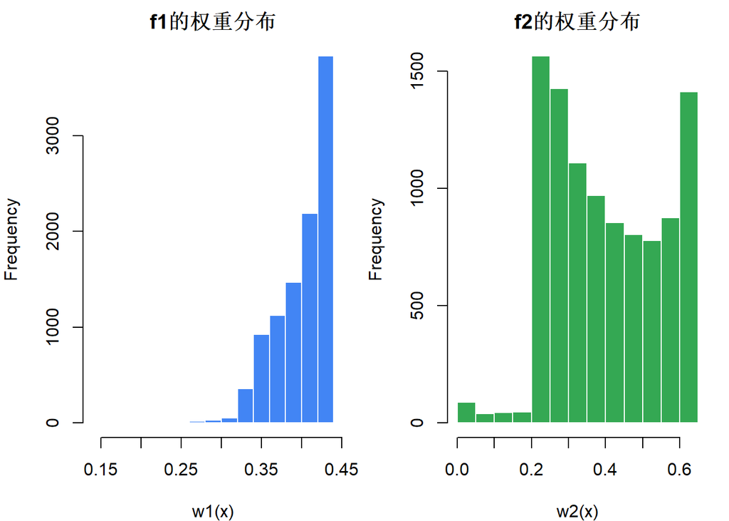

```r
par(mfrow = c(1, 2), mar = c(4, 4, 2, 1))
hist(weights_f1, main = "f1的权重分布", xlab = "w1(x)", col = "#4285F4", border = "white")
hist(weights_f2, main = "f2的权重分布", xlab = "w2(x)", col = "#34A853", border = "white")
```

```r
if (var_f1 < var_f2) {
  cat("结论: f1的抽样方差更小", "\n")
} else {
  cat("结论: f2的抽样方差更小", "\n")
}
```

```
## 结论: f1的抽样方差更小
```

## 4 问题4

Monte Carlo experiment

(2)Use R function rbenchmark::benchmark to count computation time(with 1000 replications), denoted by a_n

(3)Regress a_n on t_n :=nlog(n), and graphically show the results(scatter plot regression line).

### 4.1 实验代码

```r
# 加载所需工具包
library(rbenchmark)
library(ggplot2)
library(dplyr)
sample_sizes <- c(10000, 20900, 40000, 60000, 80000)
iterations <- 1000

benchmark_data <- data.frame(
  sample_size = numeric(),
  avg_time = numeric()
)

for (current_n in sample_sizes) {
  cat("正在处理样本量 n =", current_n, "，重复实验", iterations, "次...\n")

  performance <- benchmark(
    expr = sort(sample(1:current_n, current_n, replace = FALSE)),
    replications = iterations,
    columns = "elapsed"
  )

  benchmark_data <- bind_rows(benchmark_data,
    data.frame(
      sample_size = current_n,
      avg_time = performance$elapsed / iterations
    )
  )
}
```

```
## 正在处理样本量 n = 10000 ，重复实验 1000 次...
## 正在处理样本量 n = 20900 ，重复实验 1000 次...
## 正在处理样本量 n = 40000 ，重复实验 1000 次...
## 正在处理样本量 n = 60000 ，重复实验 1000 次...
## 正在处理样本量 n = 80000 ，重复实验 1000 次...
```

```r
benchmark_data <- benchmark_data %>%
  mutate(theoretical_term = sample_size * log(sample_size))

regression_model <- lm(avg_time ~ theoretical_term, data = benchmark_data)
cat("\n线性回归分析结果：\n")
```

```
##
## 线性回归分析结果：
```

```r
print(summary(regression_model))
```

```
##
## Call:
## lm(formula = avg_time ~ theoretical_term, data = benchmark_data)
##
## Residuals:
##          1          2          3          4          5
##  1.132e-04 -5.114e-05 -7.224e-05 -8.887e-05  9.909e-05
##
## Coefficients:
##                   Estimate Std. Error t value Pr(>|t|)
## (Intercept)      1.576e-05  9.319e-05   0.169    0.876
## theoretical_term 8.155e-09  1.711e-10  47.655 2.03e-05 ***
## ---
## Signif. codes:  0 '***' 0.001 '**' 0.01 '*' 0.05 '.' 0.1 ' ' 1
##
## Residual standard error: 0.0001131 on 3 degrees of freedom
## Multiple R-squared:  0.9987, Adjusted R-squared:  0.9982
## F-statistic:  2271 on 1 and 3 DF,  p-value: 2.035e-05
```

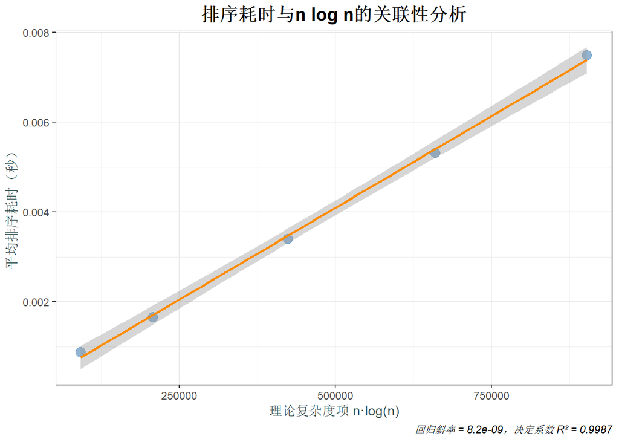

```r
plot_result <- ggplot(benchmark_data, aes(x = theoretical_term, y = avg_time)) +
  geom_point(color = "steelblue", size = 3.5, alpha = 0.6) +
  geom_smooth(method = "lm", formula = y ~ x, se = TRUE, color = "darkorange") +
  labs(
    title = "排序耗时与n log n的关联性分析",
    x = "理论复杂度项 n·log(n)",
    y = "平均排序耗时（秒）",
    caption = paste0("回归斜率 = ", round(coef(regression_model)[[2]], 10),
                     "，决定系数 R² = ", round(summary(regression_model)$r.squared, 4))
  ) +
  theme_bw() +
  theme(
    plot.title = element_text(hjust = 0.5, size = 15, face = "bold"),
    axis.title.x = element_text(size = 11, color = "darkslategray"),
    axis.title.y = element_text(size = 11, color = "darkslategray"),
    plot.caption = element_text(face = "italic")
  )

print(plot_result)
```